# Risk Factor Analysis

## Outcome Variable

**Outcome Variable:** y_rate_haz

## Predictor Variables

**Intervention Variable:** cleanck

**Adjustment Set:**

unadjusted

## Stratifying Variables

The analysis was stratified on these variable(s):

- agecat
- studyid
- country

## Data Summary

| agecat | studyid | country | cleanck | n_cell | n |
| --- | --- | --- | --- | --- | --- |
| 0-3 months | ki0047075b-MAL-ED | PERU | 0 | 0 | 1 |
| 0-3 months | ki0047075b-MAL-ED | PERU | 1 | 1 | 1 |
| 0-3 months | ki0047075b-MAL-ED | SOUTH AFRICA | 0 | 1 | 2 |
| 0-3 months | ki0047075b-MAL-ED | SOUTH AFRICA | 1 | 1 | 2 |
| 0-3 months | ki1000108-CMC-V-BCS-2002 | INDIA | 0 | 48 | 87 |
| 0-3 months | ki1000108-CMC-V-BCS-2002 | INDIA | 1 | 39 | 87 |
| 0-3 months | ki1000108-IRC | INDIA | 0 | 157 | 369 |
| 0-3 months | ki1000108-IRC | INDIA | 1 | 212 | 369 |
| 0-3 months | ki1017093b-PROVIDE | BANGLADESH | 0 | 109 | 634 |
| 0-3 months | ki1017093b-PROVIDE | BANGLADESH | 1 | 525 | 634 |
| 0-3 months | ki1017093c-NIH-Crypto | BANGLADESH | 0 | 213 | 546 |
| 0-3 months | ki1017093c-NIH-Crypto | BANGLADESH | 1 | 333 | 546 |
| 3-6 months | ki0047075b-MAL-ED | SOUTH AFRICA | 0 | 0 | 1 |
| 3-6 months | ki0047075b-MAL-ED | SOUTH AFRICA | 1 | 1 | 1 |
| 3-6 months | ki1000108-CMC-V-BCS-2002 | INDIA | 0 | 174 | 307 |
| 3-6 months | ki1000108-CMC-V-BCS-2002 | INDIA | 1 | 133 | 307 |
| 3-6 months | ki1000108-IRC | INDIA | 0 | 166 | 390 |
| 3-6 months | ki1000108-IRC | INDIA | 1 | 224 | 390 |
| 3-6 months | ki1017093b-PROVIDE | BANGLADESH | 0 | 99 | 574 |
| 3-6 months | ki1017093b-PROVIDE | BANGLADESH | 1 | 475 | 574 |
| 3-6 months | ki1017093c-NIH-Crypto | BANGLADESH | 0 | 212 | 527 |
| 3-6 months | ki1017093c-NIH-Crypto | BANGLADESH | 1 | 315 | 527 |
| 3-6 months | ki1113344-GMS-Nepal | NEPAL | 0 | 840 | 852 |
| 3-6 months | ki1113344-GMS-Nepal | NEPAL | 1 | 12 | 852 |
| 6-12 months | ki0047075b-MAL-ED | SOUTH AFRICA | 0 | 0 | 1 |
| 6-12 months | ki0047075b-MAL-ED | SOUTH AFRICA | 1 | 1 | 1 |
| 6-12 months | ki1000108-CMC-V-BCS-2002 | INDIA | 0 | 185 | 323 |
| 6-12 months | ki1000108-CMC-V-BCS-2002 | INDIA | 1 | 138 | 323 |
| 6-12 months | ki1000108-IRC | INDIA | 0 | 164 | 391 |
| 6-12 months | ki1000108-IRC | INDIA | 1 | 227 | 391 |
| 6-12 months | ki1017093b-PROVIDE | BANGLADESH | 0 | 96 | 545 |
| 6-12 months | ki1017093b-PROVIDE | BANGLADESH | 1 | 449 | 545 |
| 6-12 months | ki1017093c-NIH-Crypto | BANGLADESH | 0 | 214 | 516 |
| 6-12 months | ki1017093c-NIH-Crypto | BANGLADESH | 1 | 302 | 516 |
| 6-12 months | ki1113344-GMS-Nepal | NEPAL | 0 | 840 | 856 |
| 6-12 months | ki1113344-GMS-Nepal | NEPAL | 1 | 16 | 856 |
| 12-24 months | ki0047075b-MAL-ED | SOUTH AFRICA | 0 | 0 | 1 |
| 12-24 months | ki0047075b-MAL-ED | SOUTH AFRICA | 1 | 1 | 1 |
| 12-24 months | ki1000108-CMC-V-BCS-2002 | INDIA | 0 | 191 | 324 |
| 12-24 months | ki1000108-CMC-V-BCS-2002 | INDIA | 1 | 133 | 324 |
| 12-24 months | ki1000108-IRC | INDIA | 0 | 163 | 387 |
| 12-24 months | ki1000108-IRC | INDIA | 1 | 224 | 387 |
| 12-24 months | ki1017093b-PROVIDE | BANGLADESH | 0 | 80 | 458 |
| 12-24 months | ki1017093b-PROVIDE | BANGLADESH | 1 | 378 | 458 |
| 12-24 months | ki1017093c-NIH-Crypto | BANGLADESH | 0 | 211 | 396 |
| 12-24 months | ki1017093c-NIH-Crypto | BANGLADESH | 1 | 185 | 396 |
| 12-24 months | ki1113344-GMS-Nepal | NEPAL | 0 | 646 | 656 |
| 12-24 months | ki1113344-GMS-Nepal | NEPAL | 1 | 10 | 656 |

The following strata were considered:

- agecat: 0-3 months, studyid: ki0047075b-MAL-ED, country: PERU
- agecat: 0-3 months, studyid: ki0047075b-MAL-ED, country: SOUTH AFRICA
- agecat: 0-3 months, studyid: ki1000108-CMC-V-BCS-2002, country: INDIA
- agecat: 0-3 months, studyid: ki1000108-IRC, country: INDIA
- agecat: 0-3 months, studyid: ki1017093b-PROVIDE, country: BANGLADESH
- agecat: 0-3 months, studyid: ki1017093c-NIH-Crypto, country: BANGLADESH
- agecat: 12-24 months, studyid: ki0047075b-MAL-ED, country: SOUTH AFRICA
- agecat: 12-24 months, studyid: ki1000108-CMC-V-BCS-2002, country: INDIA
- agecat: 12-24 months, studyid: ki1000108-IRC, country: INDIA
- agecat: 12-24 months, studyid: ki1017093b-PROVIDE, country: BANGLADESH
- agecat: 12-24 months, studyid: ki1017093c-NIH-Crypto, country: BANGLADESH
- agecat: 12-24 months, studyid: ki1113344-GMS-Nepal, country: NEPAL
- agecat: 3-6 months, studyid: ki0047075b-MAL-ED, country: SOUTH AFRICA
- agecat: 3-6 months, studyid: ki1000108-CMC-V-BCS-2002, country: INDIA
- agecat: 3-6 months, studyid: ki1000108-IRC, country: INDIA
- agecat: 3-6 months, studyid: ki1017093b-PROVIDE, country: BANGLADESH
- agecat: 3-6 months, studyid: ki1017093c-NIH-Crypto, country: BANGLADESH
- agecat: 3-6 months, studyid: ki1113344-GMS-Nepal, country: NEPAL
- agecat: 6-12 months, studyid: ki0047075b-MAL-ED, country: SOUTH AFRICA
- agecat: 6-12 months, studyid: ki1000108-CMC-V-BCS-2002, country: INDIA
- agecat: 6-12 months, studyid: ki1000108-IRC, country: INDIA
- agecat: 6-12 months, studyid: ki1017093b-PROVIDE, country: BANGLADESH
- agecat: 6-12 months, studyid: ki1017093c-NIH-Crypto, country: BANGLADESH
- agecat: 6-12 months, studyid: ki1113344-GMS-Nepal, country: NEPAL

### Dropped Strata

Some strata were dropped due to rare outcomes:

- agecat: 0-3 months, studyid: ki0047075b-MAL-ED, country: PERU
- agecat: 0-3 months, studyid: ki0047075b-MAL-ED, country: SOUTH AFRICA
- agecat: 3-6 months, studyid: ki0047075b-MAL-ED, country: SOUTH AFRICA
- agecat: 6-12 months, studyid: ki0047075b-MAL-ED, country: SOUTH AFRICA
- agecat: 12-24 months, studyid: ki0047075b-MAL-ED, country: SOUTH AFRICA

## Methods Detail

We’re interested in the causal parameters $E[Y_a]$ for all values of $a \in \mathcal{A}$. These parameters represent the mean outcome if, possibly contrary to fact, we intervened to set all units to have $A=a$. Under the randomization and positivity assumptions, these are identified by the statistical parameters $\psi_a=E_W[E_{Y|A,W}(Y|A=a,W)]$. In addition, we’re interested in the mean of $Y$, $E[Y]$ under no intervention (the observed mean). We will estimate these parameters by using SuperLearner to fit the relevant likelihood factors – $E_{Y|A,W}(Y|A=a,W)$ and $p(A=a|W)$, and then updating our likelihood fit using a joint TMLE.

For unadjusted analyses ($W=\{\}$), initial likelihoods were estimated using Lrnr_glm to estimate the simple $E(Y|A)$ and Lrnr_mean to estimate $p(A)$. For adjusted analyses, a small library containing Lrnr_glmnet, Lrnr_xgboost, and Lrnr_mean was used.

Having estimated these parameters, we will then use the delta method to estimate relative risks and attributable risks relative to a prespecified baseline level of $A$.

# Results Detail

## Results Plots

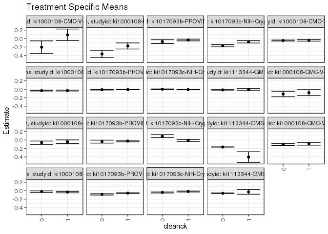

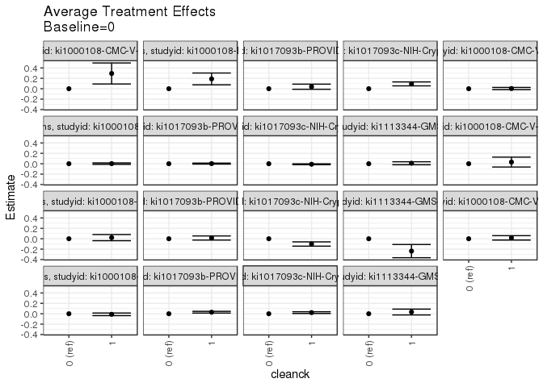

## Results Table

### Parameter: TSM

| agecat | studyid | country | intervention_level | baseline_level | estimate | ci_lower | ci_upper |
| --- | --- | --- | --- | --- | --- | --- | --- |
| 0-3 months | ki1000108-CMC-V-BCS-2002 | INDIA | 0 | NA | -0.2047890 | -0.3549392 | -0.0546387 |
| 0-3 months | ki1000108-CMC-V-BCS-2002 | INDIA | 1 | NA | 0.0885433 | -0.0473345 | 0.2244210 |
| 0-3 months | ki1000108-IRC | INDIA | 0 | NA | -0.3639352 | -0.4520356 | -0.2758348 |
| 0-3 months | ki1000108-IRC | INDIA | 1 | NA | -0.1753414 | -0.2469181 | -0.1037646 |
| 0-3 months | ki1017093b-PROVIDE | BANGLADESH | 0 | NA | -0.0730675 | -0.1184162 | -0.0277188 |
| 0-3 months | ki1017093b-PROVIDE | BANGLADESH | 1 | NA | -0.0347217 | -0.0544705 | -0.0149730 |
| 0-3 months | ki1017093c-NIH-Crypto | BANGLADESH | 0 | NA | -0.1705605 | -0.1964209 | -0.1447001 |
| 0-3 months | ki1017093c-NIH-Crypto | BANGLADESH | 1 | NA | -0.0778396 | -0.1057726 | -0.0499065 |
| 3-6 months | ki1000108-CMC-V-BCS-2002 | INDIA | 0 | NA | -0.1116598 | -0.1764945 | -0.0468252 |
| 3-6 months | ki1000108-CMC-V-BCS-2002 | INDIA | 1 | NA | -0.0800404 | -0.1498831 | -0.0101977 |
| 3-6 months | ki1000108-IRC | INDIA | 0 | NA | -0.0642886 | -0.1031990 | -0.0253782 |
| 3-6 months | ki1000108-IRC | INDIA | 1 | NA | -0.0425010 | -0.0870207 | 0.0020187 |
| 3-6 months | ki1017093b-PROVIDE | BANGLADESH | 0 | NA | -0.0390570 | -0.0741457 | -0.0039683 |
| 3-6 months | ki1017093b-PROVIDE | BANGLADESH | 1 | NA | -0.0247805 | -0.0432605 | -0.0063004 |
| 3-6 months | ki1017093c-NIH-Crypto | BANGLADESH | 0 | NA | 0.0907843 | 0.0564599 | 0.1251088 |
| 3-6 months | ki1017093c-NIH-Crypto | BANGLADESH | 1 | NA | -0.0104667 | -0.0328936 | 0.0119601 |
| 3-6 months | ki1113344-GMS-Nepal | NEPAL | 0 | NA | -0.1661667 | -0.1859442 | -0.1463891 |
| 3-6 months | ki1113344-GMS-Nepal | NEPAL | 1 | NA | -0.4039617 | -0.5298498 | -0.2780737 |
| 6-12 months | ki1000108-CMC-V-BCS-2002 | INDIA | 0 | NA | -0.1065818 | -0.1327180 | -0.0804456 |
| 6-12 months | ki1000108-CMC-V-BCS-2002 | INDIA | 1 | NA | -0.0896305 | -0.1225513 | -0.0567097 |
| 6-12 months | ki1000108-IRC | INDIA | 0 | NA | -0.0212370 | -0.0389340 | -0.0035399 |
| 6-12 months | ki1000108-IRC | INDIA | 1 | NA | -0.0320038 | -0.0495944 | -0.0144132 |
| 6-12 months | ki1017093b-PROVIDE | BANGLADESH | 0 | NA | -0.0872260 | -0.1022424 | -0.0722096 |
| 6-12 months | ki1017093b-PROVIDE | BANGLADESH | 1 | NA | -0.0573531 | -0.0650571 | -0.0496491 |
| 6-12 months | ki1017093c-NIH-Crypto | BANGLADESH | 0 | NA | -0.0413260 | -0.0536163 | -0.0290357 |
| 6-12 months | ki1017093c-NIH-Crypto | BANGLADESH | 1 | NA | -0.0190424 | -0.0305521 | -0.0075326 |
| 6-12 months | ki1113344-GMS-Nepal | NEPAL | 0 | NA | -0.0615046 | -0.0703937 | -0.0526155 |
| 6-12 months | ki1113344-GMS-Nepal | NEPAL | 1 | NA | -0.0282194 | -0.0835507 | 0.0271120 |
| 12-24 months | ki1000108-CMC-V-BCS-2002 | INDIA | 0 | NA | -0.0468750 | -0.0589445 | -0.0348056 |
| 12-24 months | ki1000108-CMC-V-BCS-2002 | INDIA | 1 | NA | -0.0435701 | -0.0612828 | -0.0258575 |
| 12-24 months | ki1000108-IRC | INDIA | 0 | NA | -0.0323427 | -0.0416314 | -0.0230540 |
| 12-24 months | ki1000108-IRC | INDIA | 1 | NA | -0.0305587 | -0.0409948 | -0.0201225 |
| 12-24 months | ki1017093b-PROVIDE | BANGLADESH | 0 | NA | -0.0099610 | -0.0183649 | -0.0015571 |
| 12-24 months | ki1017093b-PROVIDE | BANGLADESH | 1 | NA | -0.0077931 | -0.0120932 | -0.0034929 |
| 12-24 months | ki1017093c-NIH-Crypto | BANGLADESH | 0 | NA | 0.0016647 | -0.0042783 | 0.0076076 |
| 12-24 months | ki1017093c-NIH-Crypto | BANGLADESH | 1 | NA | -0.0084841 | -0.0147812 | -0.0021870 |
| 12-24 months | ki1113344-GMS-Nepal | NEPAL | 0 | NA | -0.0149712 | -0.0204173 | -0.0095251 |
| 12-24 months | ki1113344-GMS-Nepal | NEPAL | 1 | NA | -0.0056472 | -0.0340069 | 0.0227125 |

### Parameter: E(Y)

| agecat | studyid | country | intervention_level | baseline_level | estimate | ci_lower | ci_upper |
| --- | --- | --- | --- | --- | --- | --- | --- |
| 0-3 months | ki1000108-CMC-V-BCS-2002 | INDIA | NA | NA | -0.0732952 | -0.1806423 | 0.0340519 |
| 0-3 months | ki1000108-IRC | INDIA | NA | NA | -0.2555832 | -0.3120360 | -0.1991304 |
| 0-3 months | ki1017093b-PROVIDE | BANGLADESH | NA | NA | -0.0413143 | -0.0594662 | -0.0231624 |
| 0-3 months | ki1017093c-NIH-Crypto | BANGLADESH | NA | NA | -0.1140109 | -0.1341708 | -0.0938510 |
| 3-6 months | ki1000108-CMC-V-BCS-2002 | INDIA | NA | NA | -0.0979615 | -0.1455947 | -0.0503283 |
| 3-6 months | ki1000108-IRC | INDIA | NA | NA | -0.0517747 | -0.0822588 | -0.0212906 |
| 3-6 months | ki1017093b-PROVIDE | BANGLADESH | NA | NA | -0.0272428 | -0.0436954 | -0.0107902 |
| 3-6 months | ki1017093c-NIH-Crypto | BANGLADESH | NA | NA | 0.0302642 | 0.0105575 | 0.0499710 |
| 3-6 months | ki1113344-GMS-Nepal | NEPAL | NA | NA | -0.1695159 | -0.1892757 | -0.1497561 |
| 6-12 months | ki1000108-CMC-V-BCS-2002 | INDIA | NA | NA | -0.0993395 | -0.1199006 | -0.0787784 |
| 6-12 months | ki1000108-IRC | INDIA | NA | NA | -0.0274878 | -0.0401239 | -0.0148518 |
| 6-12 months | ki1017093b-PROVIDE | BANGLADESH | NA | NA | -0.0626151 | -0.0695574 | -0.0556729 |
| 6-12 months | ki1017093c-NIH-Crypto | BANGLADESH | NA | NA | -0.0282840 | -0.0367845 | -0.0197836 |
| 6-12 months | ki1113344-GMS-Nepal | NEPAL | NA | NA | -0.0608825 | -0.0696769 | -0.0520880 |
| 12-24 months | ki1000108-CMC-V-BCS-2002 | INDIA | NA | NA | -0.0455184 | -0.0556929 | -0.0353439 |
| 12-24 months | ki1000108-IRC | INDIA | NA | NA | -0.0313101 | -0.0385075 | -0.0241127 |
| 12-24 months | ki1017093b-PROVIDE | BANGLADESH | NA | NA | -0.0081718 | -0.0120131 | -0.0043304 |
| 12-24 months | ki1017093c-NIH-Crypto | BANGLADESH | NA | NA | -0.0030765 | -0.0074275 | 0.0012744 |
| 12-24 months | ki1113344-GMS-Nepal | NEPAL | NA | NA | -0.0148291 | -0.0202110 | -0.0094472 |

### Parameter: ATE

| agecat | studyid | country | intervention_level | baseline_level | estimate | ci_lower | ci_upper |
| --- | --- | --- | --- | --- | --- | --- | --- |
| 0-3 months | ki1000108-CMC-V-BCS-2002 | INDIA | 0 | 0 | 0.0000000 | 0.0000000 | 0.0000000 |
| 0-3 months | ki1000108-CMC-V-BCS-2002 | INDIA | 1 | 0 | 0.2933322 | 0.0908283 | 0.4958362 |
| 0-3 months | ki1000108-IRC | INDIA | 0 | 0 | 0.0000000 | 0.0000000 | 0.0000000 |
| 0-3 months | ki1000108-IRC | INDIA | 1 | 0 | 0.1885938 | 0.0750821 | 0.3021055 |
| 0-3 months | ki1017093b-PROVIDE | BANGLADESH | 0 | 0 | 0.0000000 | 0.0000000 | 0.0000000 |
| 0-3 months | ki1017093b-PROVIDE | BANGLADESH | 1 | 0 | 0.0383458 | -0.0111165 | 0.0878081 |
| 0-3 months | ki1017093c-NIH-Crypto | BANGLADESH | 0 | 0 | 0.0000000 | 0.0000000 | 0.0000000 |
| 0-3 months | ki1017093c-NIH-Crypto | BANGLADESH | 1 | 0 | 0.0927209 | 0.0546550 | 0.1307869 |
| 3-6 months | ki1000108-CMC-V-BCS-2002 | INDIA | 0 | 0 | 0.0000000 | 0.0000000 | 0.0000000 |
| 3-6 months | ki1000108-CMC-V-BCS-2002 | INDIA | 1 | 0 | 0.0316194 | -0.0636776 | 0.1269165 |
| 3-6 months | ki1000108-IRC | INDIA | 0 | 0 | 0.0000000 | 0.0000000 | 0.0000000 |
| 3-6 months | ki1000108-IRC | INDIA | 1 | 0 | 0.0217876 | -0.0373396 | 0.0809148 |
| 3-6 months | ki1017093b-PROVIDE | BANGLADESH | 0 | 0 | 0.0000000 | 0.0000000 | 0.0000000 |
| 3-6 months | ki1017093b-PROVIDE | BANGLADESH | 1 | 0 | 0.0142765 | -0.0253811 | 0.0539342 |
| 3-6 months | ki1017093c-NIH-Crypto | BANGLADESH | 0 | 0 | 0.0000000 | 0.0000000 | 0.0000000 |
| 3-6 months | ki1017093c-NIH-Crypto | BANGLADESH | 1 | 0 | -0.1012511 | -0.1422527 | -0.0602495 |
| 3-6 months | ki1113344-GMS-Nepal | NEPAL | 0 | 0 | 0.0000000 | 0.0000000 | 0.0000000 |
| 3-6 months | ki1113344-GMS-Nepal | NEPAL | 1 | 0 | -0.2377951 | -0.3652272 | -0.1103630 |
| 6-12 months | ki1000108-CMC-V-BCS-2002 | INDIA | 0 | 0 | 0.0000000 | 0.0000000 | 0.0000000 |
| 6-12 months | ki1000108-CMC-V-BCS-2002 | INDIA | 1 | 0 | 0.0169513 | -0.0250829 | 0.0589856 |
| 6-12 months | ki1000108-IRC | INDIA | 0 | 0 | 0.0000000 | 0.0000000 | 0.0000000 |
| 6-12 months | ki1000108-IRC | INDIA | 1 | 0 | -0.0107669 | -0.0357191 | 0.0141854 |
| 6-12 months | ki1017093b-PROVIDE | BANGLADESH | 0 | 0 | 0.0000000 | 0.0000000 | 0.0000000 |
| 6-12 months | ki1017093b-PROVIDE | BANGLADESH | 1 | 0 | 0.0298728 | 0.0129955 | 0.0467502 |
| 6-12 months | ki1017093c-NIH-Crypto | BANGLADESH | 0 | 0 | 0.0000000 | 0.0000000 | 0.0000000 |
| 6-12 months | ki1017093c-NIH-Crypto | BANGLADESH | 1 | 0 | 0.0222836 | 0.0054454 | 0.0391218 |
| 6-12 months | ki1113344-GMS-Nepal | NEPAL | 0 | 0 | 0.0000000 | 0.0000000 | 0.0000000 |
| 6-12 months | ki1113344-GMS-Nepal | NEPAL | 1 | 0 | 0.0332852 | -0.0227556 | 0.0893261 |
| 12-24 months | ki1000108-CMC-V-BCS-2002 | INDIA | 0 | 0 | 0.0000000 | 0.0000000 | 0.0000000 |
| 12-24 months | ki1000108-CMC-V-BCS-2002 | INDIA | 1 | 0 | 0.0033049 | -0.0181289 | 0.0247388 |
| 12-24 months | ki1000108-IRC | INDIA | 0 | 0 | 0.0000000 | 0.0000000 | 0.0000000 |
| 12-24 months | ki1000108-IRC | INDIA | 1 | 0 | 0.0017840 | -0.0121872 | 0.0157552 |
| 12-24 months | ki1017093b-PROVIDE | BANGLADESH | 0 | 0 | 0.0000000 | 0.0000000 | 0.0000000 |
| 12-24 months | ki1017093b-PROVIDE | BANGLADESH | 1 | 0 | 0.0021679 | -0.0072723 | 0.0116081 |
| 12-24 months | ki1017093c-NIH-Crypto | BANGLADESH | 0 | 0 | 0.0000000 | 0.0000000 | 0.0000000 |
| 12-24 months | ki1017093c-NIH-Crypto | BANGLADESH | 1 | 0 | -0.0101488 | -0.0188074 | -0.0014901 |
| 12-24 months | ki1113344-GMS-Nepal | NEPAL | 0 | 0 | 0.0000000 | 0.0000000 | 0.0000000 |
| 12-24 months | ki1113344-GMS-Nepal | NEPAL | 1 | 0 | 0.0093240 | -0.0195538 | 0.0382019 |